# Lab 4

Author

Jayson De La O

Steps 1. Read in the data First download and then read in with data.table::fread()

```r
library(tidyverse)
library(data.table)
library(leaflet)
library(dplyr)
library(devtools)
library(R.utils)
library(Hmisc)
```

```r
if (!file.exists("met_all.gz"))
  download.file(
    url = "https://raw.githubusercontent.com/USCbiostats/data-science-data/master/02_met/met_all.gz",
    destfile = "met_all.gz",
    method   = "libcurl",
    timeout  = 60
    )
met <- data.table::fread("met_all.gz")
```

Remove temperatures less than -17C Make sure there are no missing data in the key variables coded as 9999, 999, etc Generate a date variable using the functions as.Date() (hint: You will need the following to create a date paste(year, month, day, sep = “-”)). Using the data.table::week function, keep the observations of the first week of the month. Compute the mean by station of the variables temp, rh, wind.sp, vis.dist, dew.point, lat, lon, and elev. Create a region variable for NW, SW, NE, SE based on lon = -98.00 and lat = 39.71 degrees Create a categorical variable for elevation as in the lecture slides

```r
summary(met$temp)
```

```
   Min. 1st Qu.  Median    Mean 3rd Qu.    Max.    NA's
 -40.00   19.60   23.50   23.59   27.80   56.00   60089
```

```r
met <- met[temp>=-17]
summary(met$temp)
```

```
   Min. 1st Qu.  Median    Mean 3rd Qu.    Max.
 -17.00   19.60   23.50   23.59   27.80   56.00
```

```r
summary(met)
```

```
     USAFID            WBAN            year          month        day
 Min.   :690150   Min.   :  116   Min.   :2019   Min.   :8   Min.   : 1
 1st Qu.:720927   1st Qu.: 3705   1st Qu.:2019   1st Qu.:8   1st Qu.: 8
 Median :722720   Median :13841   Median :2019   Median :8   Median :16
 Mean   :723095   Mean   :29496   Mean   :2019   Mean   :8   Mean   :16
 3rd Qu.:725090   3rd Qu.:54768   3rd Qu.:2019   3rd Qu.:8   3rd Qu.:24
 Max.   :726813   Max.   :94998   Max.   :2019   Max.   :8   Max.   :31

      hour            min             lat             lon
 Min.   : 0.00   Min.   : 0.00   Min.   :24.55   Min.   :-124.29
 1st Qu.: 6.00   1st Qu.:20.00   1st Qu.:33.98   1st Qu.: -98.02
 Median :11.00   Median :48.00   Median :38.37   Median : -91.74
 Mean   :11.46   Mean   :39.23   Mean   :37.97   Mean   : -92.14
 3rd Qu.:17.00   3rd Qu.:55.00   3rd Qu.:41.96   3rd Qu.: -82.99
 Max.   :23.00   Max.   :59.00   Max.   :48.94   Max.   : -68.31

      elev           wind.dir      wind.dir.qc        wind.type.code
 Min.   : -13.0   Min.   :  3      Length:2317212     Length:2317212
 1st Qu.: 101.0   1st Qu.:120      Class :character   Class :character
 Median : 252.0   Median :180      Mode  :character   Mode  :character
 Mean   : 415.1   Mean   :185
 3rd Qu.: 400.0   3rd Qu.:260
 Max.   :9999.0   Max.   :360
                  NA's   :732171
    wind.sp       wind.sp.qc          ceiling.ht    ceiling.ht.qc
 Min.   : 0.00   Length:2317212     Min.   :    0   Min.   :1.000
 1st Qu.: 0.00   Class :character   1st Qu.: 3048   1st Qu.:5.000
 Median : 2.10   Mode  :character   Median :22000   Median :5.000
 Mean   : 2.46                      Mean   :16171   Mean   :4.945
 3rd Qu.: 3.60                      3rd Qu.:22000   3rd Qu.:5.000
 Max.   :36.00                      Max.   :22000   Max.   :9.000
 NA's   :31743                      NA's   :73442
 ceiling.ht.method    sky.cond            vis.dist      vis.dist.qc
 Length:2317212     Length:2317212     Min.   :     0   Length:2317212
 Class :character   Class :character   1st Qu.: 16093   Class :character
 Mode  :character   Mode  :character   Median : 16093   Mode  :character
                                       Mean   : 14924
                                       3rd Qu.: 16093
                                       Max.   :160000
                                       NA's   :33674
```

[output cut: 9 more lines]

```
 Min.   :-37.20   Length:2317212     Min.   : 960.5    Min.   :1.000
 1st Qu.: 13.80   Class :character   1st Qu.:1011.8    1st Qu.:5.000
 Median : 18.10   Mode  :character   Median :1014.1    Median :9.000
 Mean   : 17.02                      Mean   :1014.2    Mean   :7.696
 3rd Qu.: 21.70                      3rd Qu.:1016.4    3rd Qu.:9.000
 Max.   : 36.00                      Max.   :1059.9    Max.   :9.000
 NA's   :6295                        NA's   :1606788
       rh
 Min.   :  0.833
 1st Qu.: 55.790
 Median : 76.554
 Mean   : 71.641
 3rd Qu.: 90.629
 Max.   :100.000
 NA's   :6295
```

```r
met[met$elev==9999.0] <- NA
```

```r
met$date<-as.Date(paste(met$year, met$month, met$day, sep = "-"))
```

```r
met$week <- data.table::week(met$date)
tail(met)
```

```
   USAFID  WBAN year month day hour min    lat      lon elev wind.dir
1: 726813 94195 2019     8  31   18  56 43.650 -116.633  741       NA
2: 726813 94195 2019     8  31   19  56 43.650 -116.633  741       70
3: 726813 94195 2019     8  31   20  56 43.650 -116.633  741       NA
4: 726813 94195 2019     8  31   21  56 43.650 -116.633  741       10
5: 726813 94195 2019     8  31   22  56 43.642 -116.636  741       10
6: 726813 94195 2019     8  31   23  56 43.642 -116.636  741       40
   wind.dir.qc wind.type.code wind.sp wind.sp.qc ceiling.ht ceiling.ht.qc
1:           9              C     0.0          5      22000             5
2:           5              N     2.1          5      22000             5
3:           9              C     0.0          5      22000             5
4:           5              N     2.6          5      22000             5
5:           1              N     2.1          1      22000             1
6:           1              N     2.1          1      22000             1
   ceiling.ht.method sky.cond vis.dist vis.dist.qc vis.var vis.var.qc temp
```

[output cut: 20 more lines]

```r
start <- as.Date("2019-08-01")
end <- as.Date("2019-08-07")
```

```r
metfw<- met[met$date >= start & met$date <=end]
metfw
```

```
        USAFID  WBAN year month day hour min   lat      lon elev wind.dir
     1: 690150 93121 2019     8   1    0  56 34.30 -116.166  696      220
     2: 690150 93121 2019     8   1    1  56 34.30 -116.166  696      230
     3: 690150 93121 2019     8   1    2  56 34.30 -116.166  696      230
     4: 690150 93121 2019     8   1    3  56 34.30 -116.166  696      210
     5: 690150 93121 2019     8   1    4  56 34.30 -116.166  696      120
    ---
521698: 726813 94195 2019     8   7   19  56 43.65 -116.633  741       NA
521699: 726813 94195 2019     8   7   20  56 43.65 -116.633  741      330
521700: 726813 94195 2019     8   7   21  56 43.65 -116.633  741      320
521701: 726813 94195 2019     8   7   22  56 43.65 -116.633  741      290
521702: 726813 94195 2019     8   7   23  56 43.65 -116.633  741      340
        wind.dir.qc wind.type.code wind.sp wind.sp.qc ceiling.ht ceiling.ht.qc
     1:           5              N     5.7          5      22000             5
     2:           5              N     8.2          5      22000             5
```

[output cut: 45 more lines]

```r
metfw_avg<- metfw[,.(
   temp     = mean(temp,na.rm=TRUE),
  rh       = mean(rh,na.rm=TRUE),
  wind.sp  = mean(wind.sp,na.rm=TRUE),
  vis.dist = mean(vis.dist,na.rm=TRUE),
  dew.point  = mean(dew.point,na.rm=TRUE),
  lat      = mean(lat),
  lon      = mean(lon),
  elev     = mean(elev,na.rm=TRUE)
),by =c("USAFID")]

metfw_avg
```

```
      USAFID     temp       rh  wind.sp vis.dist dew.point      lat        lon
   1: 690150 34.07560 15.67014 3.741071 16016.38  3.402381 34.29995 -116.16595
   2: 720110 31.19246 52.32596 1.751587 15984.44 19.321429 30.78400  -98.66200
   3: 720113 24.40505 60.28099 1.563093 16068.36 15.386064 42.54300  -83.17800
   4: 720120 25.64310 88.30706 1.773064 15315.47 23.451178 32.21733  -80.69986
   5: 720137 23.16885 68.98459 1.438095 15965.28 16.398016 41.42500  -88.41900
  ---
1577: 726777 22.88205 63.14163 4.162176 15647.35 14.284103 46.35779 -104.25018
1578: 726797 20.97347 54.21198 3.317347 16051.95  9.859694 45.78783 -111.15989
1579: 726798 22.10149 46.09992 4.483168 15583.13  8.709524 45.69800 -110.44000
1580: 726810 27.97020 31.25704 2.600510 16079.85  8.080808 43.56700 -116.23901
1581: 726813 26.63452 43.90311 2.303571 16025.96 12.147619 43.64990 -116.63304
           elev
   1:  695.1548
   2:  336.0000
   3:  222.0000
   4:    6.0000
   5:  178.0000
  ---
1577:  906.0000
1578: 1356.1071
1579: 1408.0000
1580:  873.8586
1581:  741.0000
```

```r
metfw_avg$region <- ifelse(metfw_avg$lon > -98 & metfw_avg$lat > 39.71,"NE",
                       ifelse(metfw_avg$lon > -98 & metfw_avg$lat <39.71,"NW",
                              ifelse(metfw_avg$lon < -98 & metfw_avg$lat > 39.71,"SE",
                       ifelse(metfw_avg$lon < -98 & metfw_avg$lat <39.71,"SW",NA))))

unique(metfw_avg$region)
```

```
[1] "SW" "NE" "NW" "SE"
```

```r
metfw_avg[,elev_cat := fifelse(elev > 252, "high","low")]
```

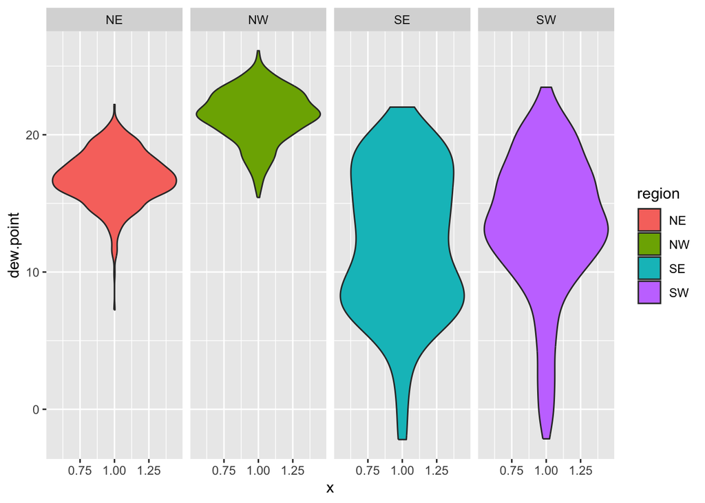

```r
metfw_avg[!is.na(wind.sp) & !is.na(dew.point) & !is.na(region)] %>%
  ggplot()+
  geom_violin(mapping=aes(x=1,y=dew.point,fill=region))+
  facet_wrap(~region,nrow=1)
```

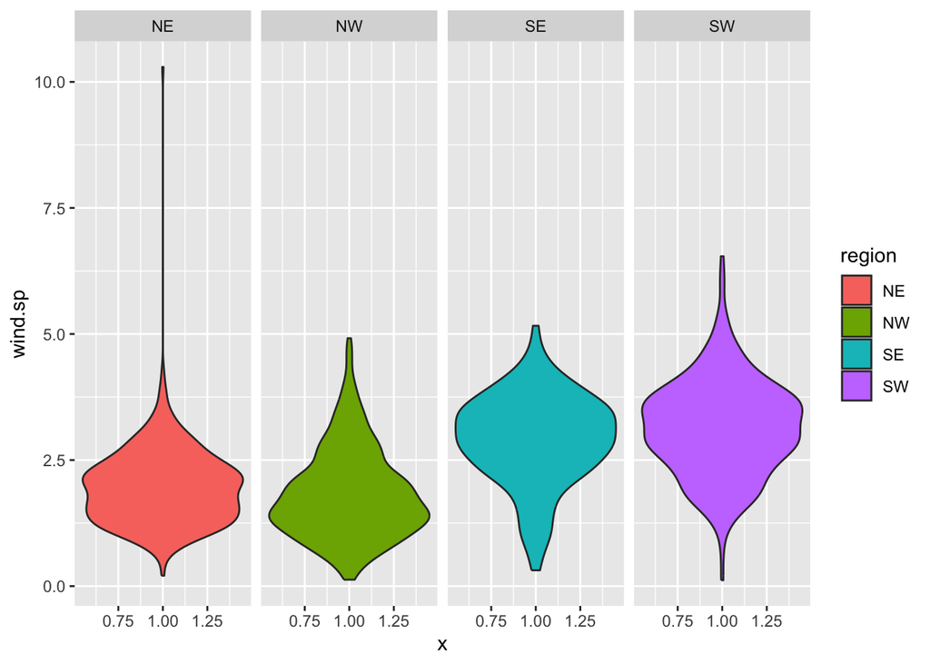

```r
metfw_avg[!is.na(wind.sp)& !is.na(dew.point) & !is.na(region)] %>%
  ggplot()+
  geom_violin(mapping=aes(x=1,y=wind.sp,fill=region))+
  facet_wrap(~region,nrow=1)
```

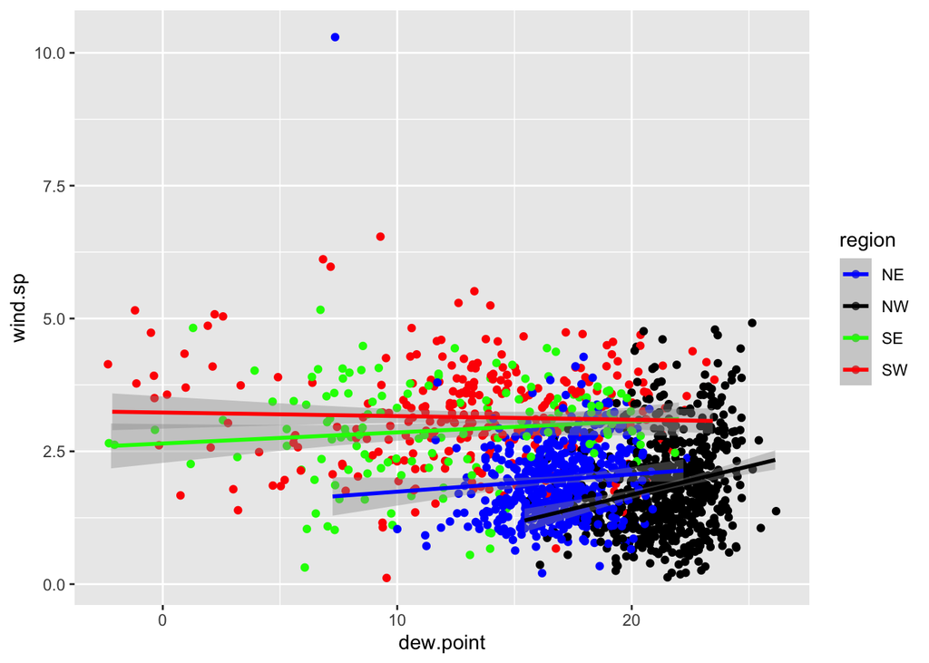

```r
metfw_avg[!is.na(wind.sp)& !is.na(dew.point) & !is.na(region)] %>%
 ggplot( aes(x=dew.point,y=wind.sp,color=region ))+
  geom_jitter(width=.2,height=0)+
  stat_smooth(method=lm,aes(group=region))+
    scale_color_manual(values=c("NE"="blue","SE"="green","NW"="black","SW"="red"))
```

The bar graph shows me that the Northwest has the highest amount of weather stations at low elevations and the souther east has the lowest amount of elevations at low elevations.At high elevations, NE has the highest amount of weather stations and the south east has the lowest amount.

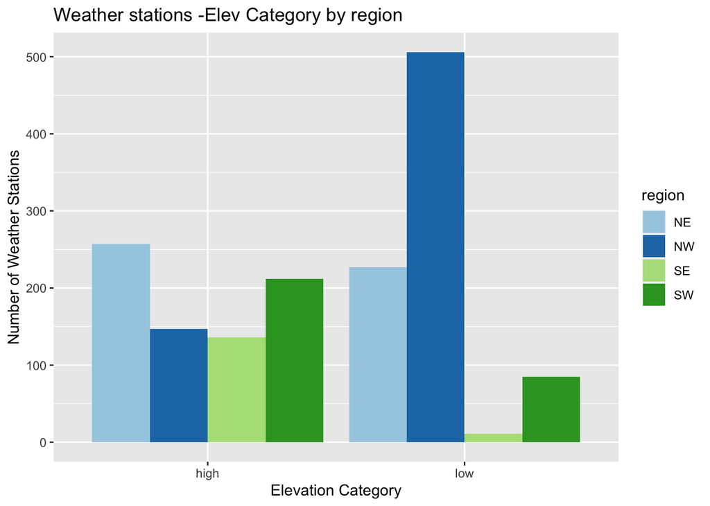

```r
metfw_avg[!is.na(elev_cat) & !is.na(region)] %>%
  ggplot(mapping=aes(x=elev_cat,fill=region))+
  geom_bar(position="dodge")+
  scale_fill_brewer(palette="Paired")+
  labs(title="Weather stations -Elev Category by region",x="Elevation Category",y="Number of Weather Stations")
```

Dew point is: NE=16.81,NW=21.36,SE=11.98, and SW=13.32. Wind speed is: NE=1.96,NW=1.83,SE=2.90,SW=3.15,

```r
metfw_avgmean<- metfw_avg[,.(
   temp     = mean(temp,na.rm=TRUE),
  wind.sp  = mean(wind.sp,na.rm=TRUE),
  dew.point  = mean(dew.point,na.rm=TRUE),
  lat      = mean(lat),
  lon      = mean(lon),
  elev     = mean(elev,na.rm=TRUE)
),by =c("region")]

metfw_avgmean
```

```
   region     temp  wind.sp dew.point      lat        lon      elev
1:     SW 25.93417 3.147686  13.31834 35.00492 -109.38666  881.0800
2:     NE 22.06862 1.963122  16.81132 42.66706  -85.20866  262.0461
3:     NW 26.02335 1.830201  21.35791 34.02412  -86.97362  154.3334
4:     SE 22.55342 2.898622  11.97769 43.00783 -108.36273 1155.5909
```

```
No summary function supplied, defaulting to `mean_se()`
```

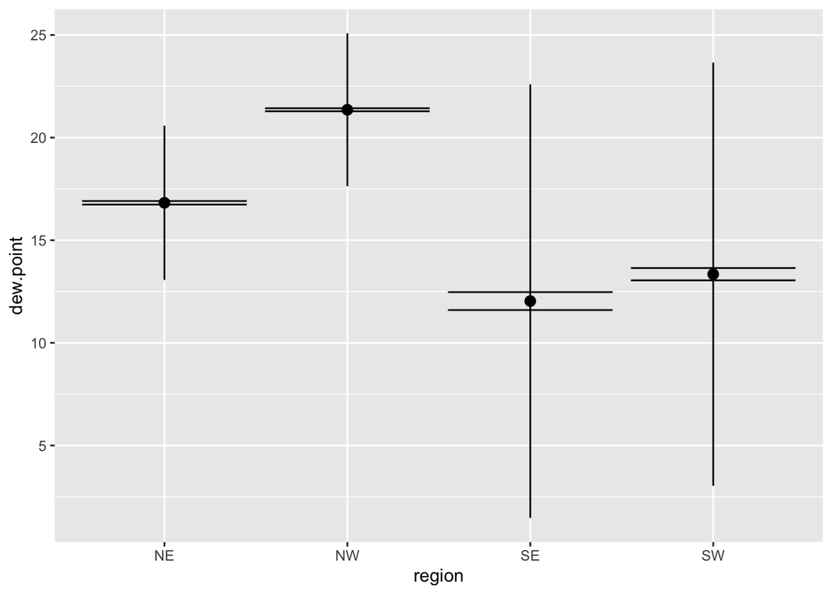

```r
metfw_avg[!is.na(dew.point) & !is.na(region) & !is.na(wind.sp)] %>%
 ggplot(mapping=aes(y=dew.point,x=region))+
  stat_summary(fun.data = "mean_sdl")+
  stat_summary(geom="errorbar")
```

```
No summary function supplied, defaulting to `mean_se()`
```

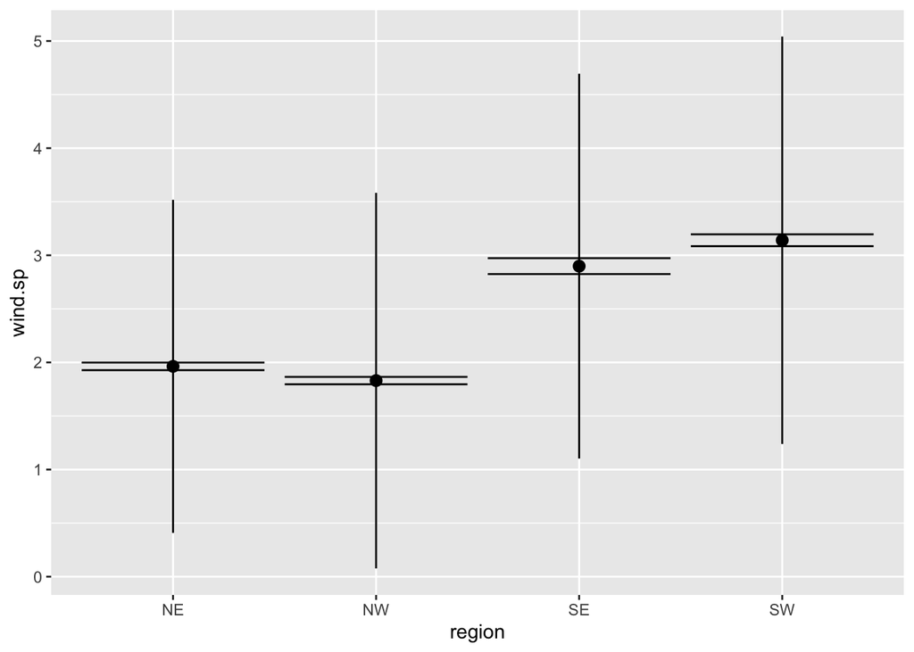

```r
metfw_avg[!is.na(dew.point) & !is.na(region) & !is.na(wind.sp)] %>%
 ggplot(mapping=aes(y=wind.sp,x=region))+
  stat_summary(fun.data = "mean_sdl")+
  stat_summary(geom="errorbar")
```

Relative humidity increases near the coasts, but overall it is higher in the East than it is in the West.

```r
met_avg2 <- met[,.(rh = mean(rh,na.rm=TRUE), lat = mean(lat), lon = mean(lon)),  by=c("USAFID")]
met_avg2 <- met_avg2[!is.na(rh)]

top10<-met_avg2[rank(-met_avg2$rh)<=10]
top10
```

```
    USAFID       rh      lat        lon
 1: 720587 89.85023 29.97600  -92.08400
 2: 720646 90.19726 37.51300 -122.50100
 3: 720649 92.32426 36.33000  -77.63500
 4: 723930 94.36362 34.71799 -120.56690
 5: 724395 91.31542 38.88334  -90.04980
 6: 724737 92.62700 28.81654  -82.31704
 7: 725513 90.81298 40.89304  -97.99680
 8: 725946 90.67555 41.78000 -124.23601
 9: 726130 90.87287 44.27000  -71.30000
10: 726436 91.10566 43.93333  -90.26622
```

```r
# Generating a color palette
rh.pal <- colorNumeric(c('darkgreen','goldenrod','brown'), domain=met_avg2$rh)
rh.pal
```

[output not shown]

```r
rhmap <- leaflet(met_avg2) %>%
  # The looks of the Map
  addProviderTiles('CartoDB.Positron') %>%
  # Some circles
  addCircles(
    lat = ~lat, lng=~lon,
                                                  # HERE IS OUR PAL!
    label = ~paste0(round(rh,2), ' %'), color = ~ rh.pal(rh),
    opacity = 1, fillOpacity = 1, radius = 500
    ) %>%
  # And a pretty legend
  addLegend('bottomleft', pal=rh.pal, values=met_avg2$rh,
          title='Relative Humidity, %', opacity=1) %>%
  addMarkers(lng=top10$lon,lat=top10$lat)

rhmap
```

[interactive chart not shown]

[figure not shown]

```r
library(ggforce)

ggplot(metfw_avg, aes(x=elev, y=temp, color = region)) +
  geom_point() +
  facet_zoom(x = Location=="SW")
```